# NDFS Synthesis Manuscript: Chlorophyll analysis

### Observed vs Fitted Values

```r
# Sample sizes for each year
df_chla_sttd |> count(Year_fct)
```

```
## # A tibble: 5 × 2
##   Year_fct     n
##   <fct>    <int>
## 1 2015        17
## 2 2016        14
## 3 2017        10
## 4 2018        14
## 5 2019        16
```

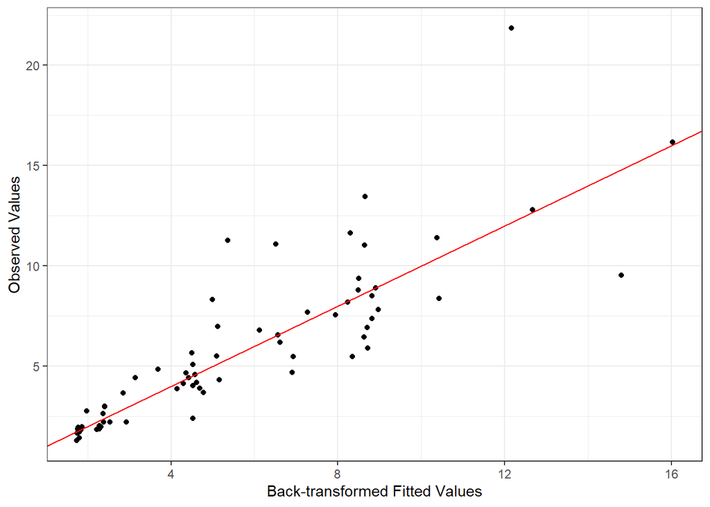

```r
plot_obs_vs_model_fit(m_gam_sttd, df_chla_sttd)
```

The model fit looks pretty decent. Note that variability does increase as the chlorophyll values increase. Now, let’s look more closely at its results.

### Model Results

#### Effect of Flow by Year

Partial effect of flow on chlorophyll:

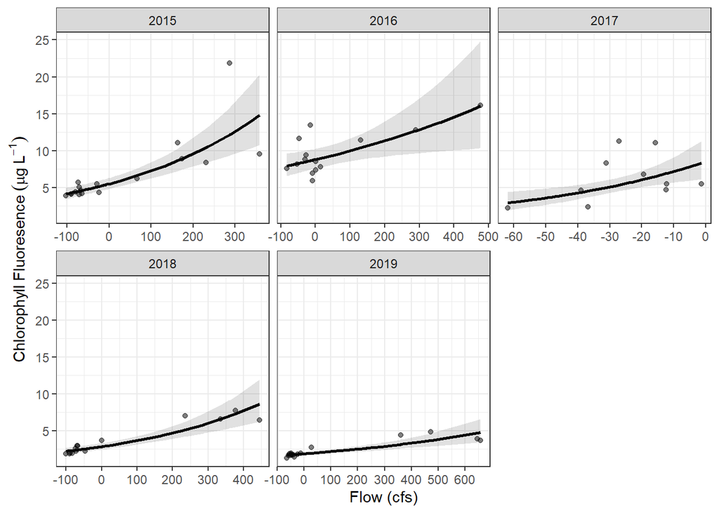

```r
# Calculate effects of flow on chlorophyll holding the non-focal variables constant -
# marginal effects/adjusted predictions
df_sttd_flow_eff <- calc_flow_yr_marg_eff(m_gam_sttd, df_chla_sttd, "Flow")

# Create effects plot
plot_eff_flow_by_yr(df_sttd_flow_eff, df_chla_sttd, "Flow")
```

#### Year Contrasts

```r
# Estimated marginal means for year
em_sttd_yr <- emmeans(m_gam_sttd, ~Year_fct)

# Tukey post-hoc contrasts
pairs(em_sttd_yr)
```

```
##  contrast                    estimate     SE df t.ratio p.value
##  Year_fct2015 - Year_fct2016   -0.400 0.0973 61  -4.110  0.0011
##  Year_fct2015 - Year_fct2017   -1.114 0.3860 61  -2.886  0.0414
##  Year_fct2015 - Year_fct2018    0.671 0.0973 61   6.899 <0.0001
##  Year_fct2015 - Year_fct2019    1.127 0.0952 61  11.841 <0.0001
##  Year_fct2016 - Year_fct2017   -0.714 0.3870 61  -1.845  0.3578
##  Year_fct2016 - Year_fct2018    1.071 0.1020 61  10.538 <0.0001
##  Year_fct2016 - Year_fct2019    1.527 0.0996 61  15.328 <0.0001
##  Year_fct2017 - Year_fct2018    1.785 0.3870 61   4.612  0.0002
##  Year_fct2017 - Year_fct2019    2.241 0.3870 61   5.797 <0.0001
##  Year_fct2018 - Year_fct2019    0.456 0.0996 61   4.574  0.0002
##
## P value adjustment: tukey method for comparing a family of 5 estimates
```

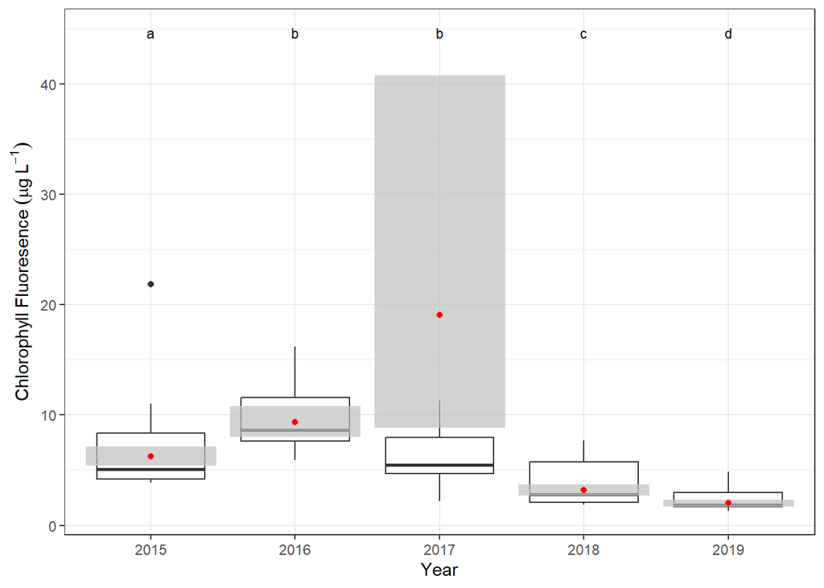

```r
# Create boxplot showing Tukey post-hoc results
boxplot_cont_yr(em_sttd_yr, df_chla_sttd)
```

Again, the model seems off for 2017. This is most likely because emmeans is using a Flow value outside of the range of flow values that occurred during 2017. I think this model is good for looking at the effects of flow by year, but not for differences between years.

## LIB

### Initial Model

```r
df_chla_lib <- ls_chla_flow_lag$LIB |>
  select(-Flow) |>
  drop_na(Flow_lag2, Chla_log)

m_gam_lib <- gam(
  Chla_log ~ Year_fct * Flow_lag2 + s(Week, bs = "cc", k = 5),
  data = df_chla_lib,
  method = "REML",
  knots = list(Week = c(0, 52))
)
```

Lets look at the model summary and diagnostics:

```r
check_gam_diagnostics(m_gam_lib)
```

```
## ==================================================
##           GAM MODEL DIAGNOSTICS
## ==================================================
##
## --- 1. MODEL SUMMARY ---
##
## Family: gaussian
## Link function: identity
##
## Formula:
## Chla_log ~ Year_fct * Flow_lag2 + s(Week, bs = "cc", k = 5)
##
## Parametric coefficients:
##                          Estimate Std. Error t value Pr(>|t|)
## (Intercept)             7.6658256  0.0942857  81.304  < 2e-16 ***
## Year_fct2016            0.6452778  0.1549420   4.165 0.000100 ***
## Year_fct2017            0.0384005  0.1587787   0.242 0.809711
## Year_fct2018           -1.8838565  0.1503589 -12.529  < 2e-16 ***
## Year_fct2019           -0.5873082  0.1625333  -3.613 0.000614 ***
## Flow_lag2               0.0020176  0.0006761   2.984 0.004091 **
## Year_fct2016:Flow_lag2 -0.0016994  0.0009587  -1.773 0.081315 .
## Year_fct2017:Flow_lag2 -0.0029788  0.0030084  -0.990 0.326019
## Year_fct2018:Flow_lag2 -0.0005373  0.0008587  -0.626 0.533858
## Year_fct2019:Flow_lag2 -0.0020531  0.0007693  -2.669 0.009752 **
## ---
## Signif. codes:  0 '***' 0.001 '**' 0.01 '*' 0.05 '.' 0.1 ' ' 1
##
## Approximate significance of smooth terms:
##           edf Ref.df     F  p-value
## s(Week) 2.237      3 12.15 6.43e-07 ***
## ---
## Signif. codes:  0 '***' 0.001 '**' 0.01 '*' 0.05 '.' 0.1 ' ' 1
##
## R-sq.(adj) =  0.867   Deviance explained = 88.7%
## -REML = 71.522  Scale est. = 0.15383   n = 73
##
## --- 2. BASIS DIMENSION CHECK (k.check) ---
##         k'      edf  k-index p-value
## s(Week)  3 2.236972 1.093003   0.735
##
## *Note: If p-value is low, the basis dimension 'k' might be too small.*
##
## --- 3. NORMALITY TEST OF RESIDUALS ---
##
##  Shapiro-Wilk normality test
##
## data:  resids
## W = 0.97299, p-value = 0.1185
##
## Result: Fail to reject H0. Residuals appear normally distributed (p >= 0.05).
##
## --- 4. GENERATING APPRAISE PLOTS ---
## Displaying: Residual QQ-plot, Residuals vs Linear Predictor, Histogram, and Observed vs Fitted.
```

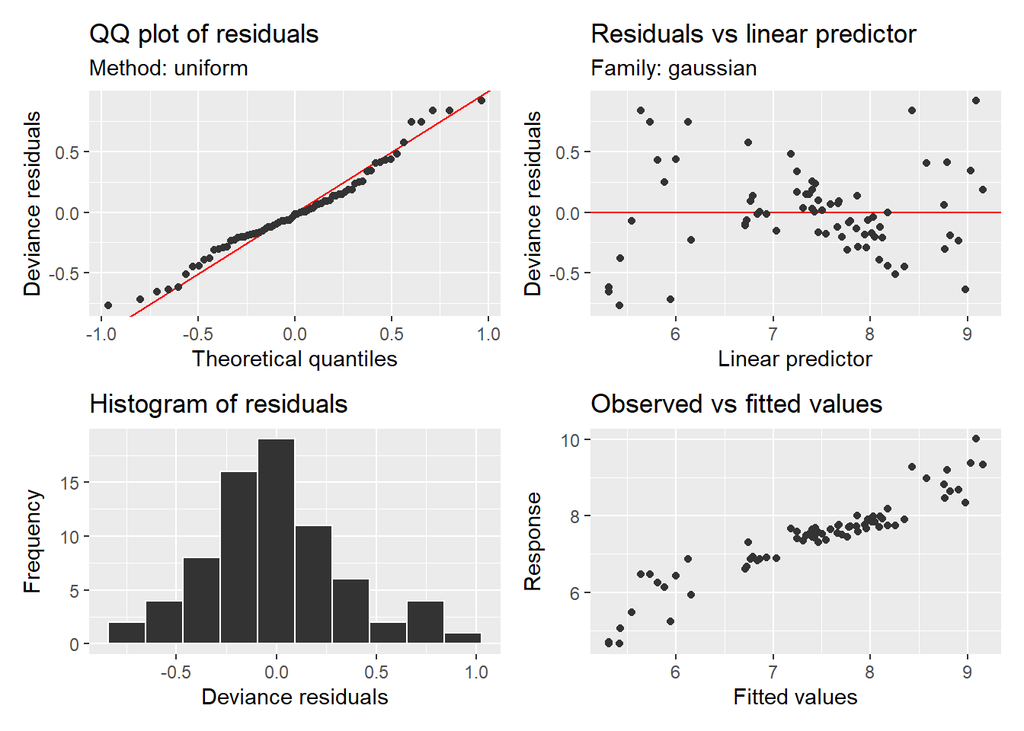

```
## --- 5. GENERATING SMOOTH TERM PLOTS ---
```

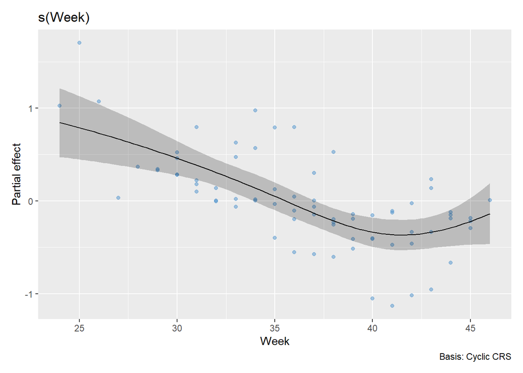

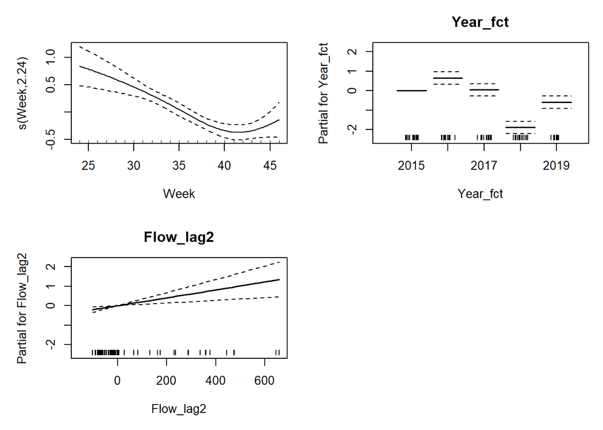

```r
check_gam_autocorr(m_gam_lib)
```

```
## ==================================================
##        GAM RESIDUAL AUTOCORRELATION CHECK
## ==================================================
##
## --- 1. LJUNG-BOX TEST FOR SERIAL CORRELATION ---
##
##  Box-Ljung test
##
## data:  resids
## X-squared = 61.921, df = 20, p-value = 3.577e-06
##
## Result: Reject H0. Significant residual autocorrelation detected (p < 0.05).
##         Your model might be missing a time/spatial trend or AR structure.
##
## --- 2. PLOTTING AUTOCORRELATION FUNCTION (ACF) ---
```

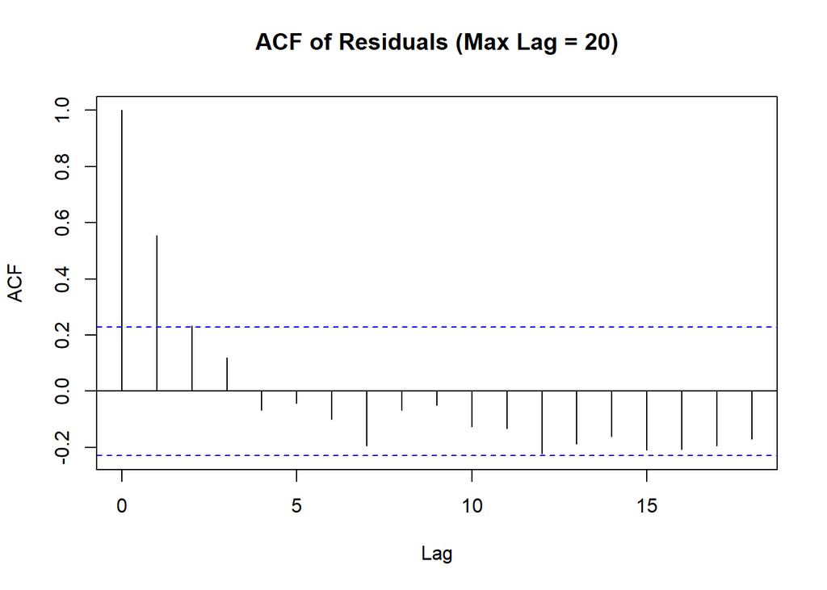

The diagnostic plots and stats look good. However, the residuals are autocorrelated.

### Model with lag terms

Now, we’ll try to deal with the residual autocorrelation. We’ll run a series of models adding 1 and 2 lag terms and compare how well they correct for autocorrelation.

```r
m_gam_lib_lag1 <- gam(
  Chla_log ~ Year_fct * Flow_lag2 + s(Week, bs = "cc", k = 5) + lag1,
  data = df_chla_lib,
  method = "REML",
  knots = list(Week = c(0, 52))
)

check_gam_autocorr(m_gam_lib_lag1)
```

```
## ==================================================
##        GAM RESIDUAL AUTOCORRELATION CHECK
## ==================================================
##
## --- 1. LJUNG-BOX TEST FOR SERIAL CORRELATION ---
##
##  Box-Ljung test
##
## data:  resids
## X-squared = 18.323, df = 20, p-value = 0.5661
##
## Result: Fail to reject H0. No significant residual autocorrelation (p >= 0.05).
##
## --- 2. PLOTTING AUTOCORRELATION FUNCTION (ACF) ---
```

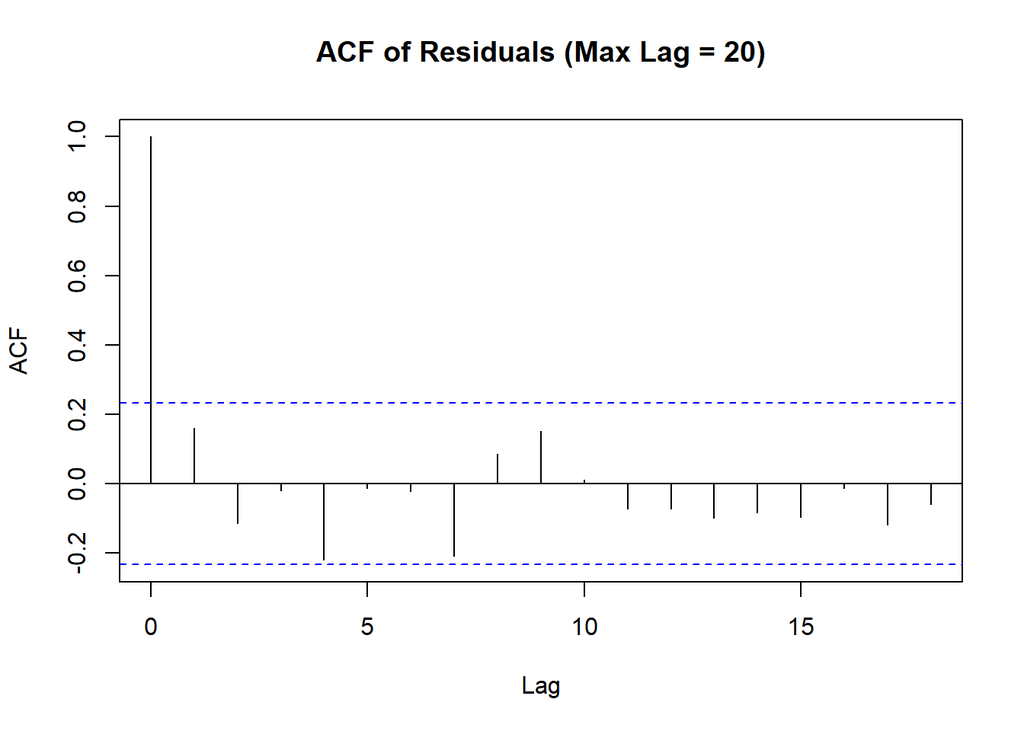

```r
m_gam_lib_lag2 <- gam(
  Chla_log ~ Year_fct * Flow_lag2 + s(Week, bs = "cc", k = 5) + lag1 + lag2,
  data = df_chla_lib,
  method = "REML",
  knots = list(Week = c(0, 52))
)

check_gam_autocorr(m_gam_lib_lag2)
```

```
## ==================================================
##        GAM RESIDUAL AUTOCORRELATION CHECK
## ==================================================
##
## --- 1. LJUNG-BOX TEST FOR SERIAL CORRELATION ---
##
##  Box-Ljung test
##
## data:  resids
## X-squared = 14.067, df = 20, p-value = 0.8271
##
## Result: Fail to reject H0. No significant residual autocorrelation (p >= 0.05).
##
## --- 2. PLOTTING AUTOCORRELATION FUNCTION (ACF) ---
```

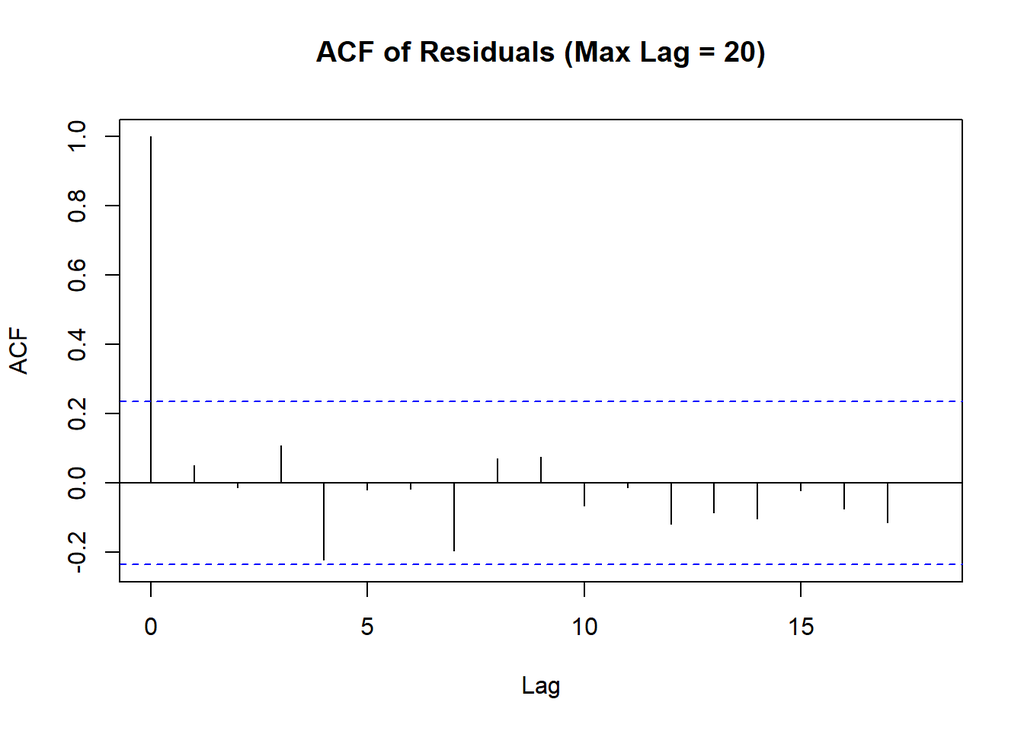

The model with 1 lag term seems to be okay with autocorrelation according to the acf plot. Adding a second lag term seems unnecessary. Let’s take a closer look at the model with 1 lag term.

```r
check_gam_diagnostics(m_gam_lib_lag1)
```

```
## ==================================================
##           GAM MODEL DIAGNOSTICS
## ==================================================
##
## --- 1. MODEL SUMMARY ---
##
## Family: gaussian
## Link function: identity
##
## Formula:
## Chla_log ~ Year_fct * Flow_lag2 + s(Week, bs = "cc", k = 5) +
##     lag1
##
## Parametric coefficients:
##                          Estimate Std. Error t value Pr(>|t|)
## (Intercept)             2.8585321  0.9062687   3.154  0.00254 **
## Year_fct2016            0.2273304  0.1603064   1.418  0.16147
## Year_fct2017            0.0046297  0.1381081   0.034  0.97337
## Year_fct2018           -0.6863587  0.2719895  -2.523  0.01436 *
## Year_fct2019           -0.2074296  0.1644704  -1.261  0.21225
## Flow_lag2               0.0007543  0.0006048   1.247  0.21724
## lag1                    0.6255969  0.1173114   5.333 1.63e-06 ***
## Year_fct2016:Flow_lag2 -0.0008179  0.0008387  -0.975  0.33348
## Year_fct2017:Flow_lag2 -0.0010118  0.0026491  -0.382  0.70389
## Year_fct2018:Flow_lag2 -0.0008527  0.0007669  -1.112  0.27072
## Year_fct2019:Flow_lag2 -0.0008209  0.0007028  -1.168  0.24750
## ---
## Signif. codes:  0 '***' 0.001 '**' 0.01 '*' 0.05 '.' 0.1 ' ' 1
##
## Approximate significance of smooth terms:
##           edf Ref.df    F p-value
## s(Week) 1.513      3 1.74  0.0352 *
## ---
## Signif. codes:  0 '***' 0.001 '**' 0.01 '*' 0.05 '.' 0.1 ' ' 1
##
## R-sq.(adj) =  0.898   Deviance explained = 91.5%
## -REML =  61.32  Scale est. = 0.11801   n = 71
##
## --- 2. BASIS DIMENSION CHECK (k.check) ---
##         k'      edf  k-index p-value
## s(Week)  3 1.512889 1.031146   0.555
##
## *Note: If p-value is low, the basis dimension 'k' might be too small.*
##
## --- 3. NORMALITY TEST OF RESIDUALS ---
##
##  Shapiro-Wilk normality test
##
## data:  resids
## W = 0.94609, p-value = 0.004201
##
## Result: Reject H0. Residuals are NOT normally distributed (p < 0.05).
##
## --- 4. GENERATING APPRAISE PLOTS ---
## Displaying: Residual QQ-plot, Residuals vs Linear Predictor, Histogram, and Observed vs Fitted.
```

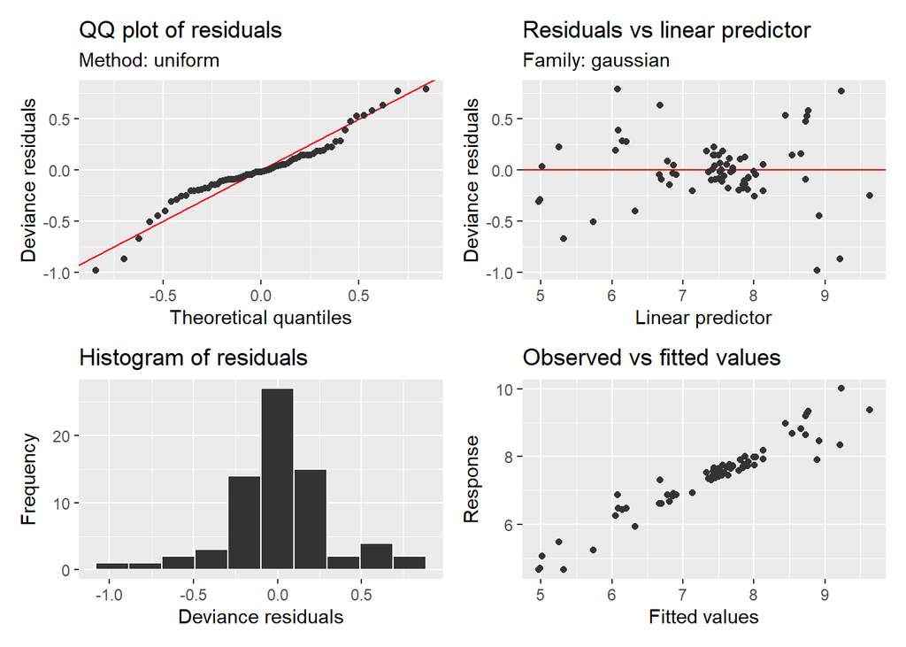

```
## --- 5. GENERATING SMOOTH TERM PLOTS ---
```

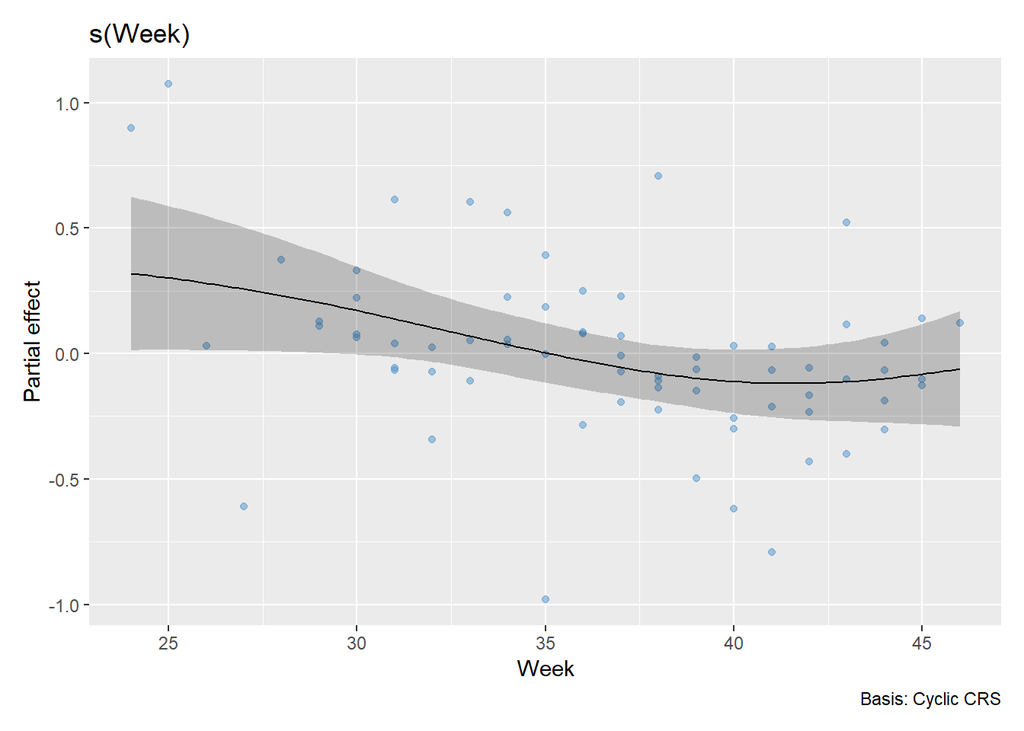

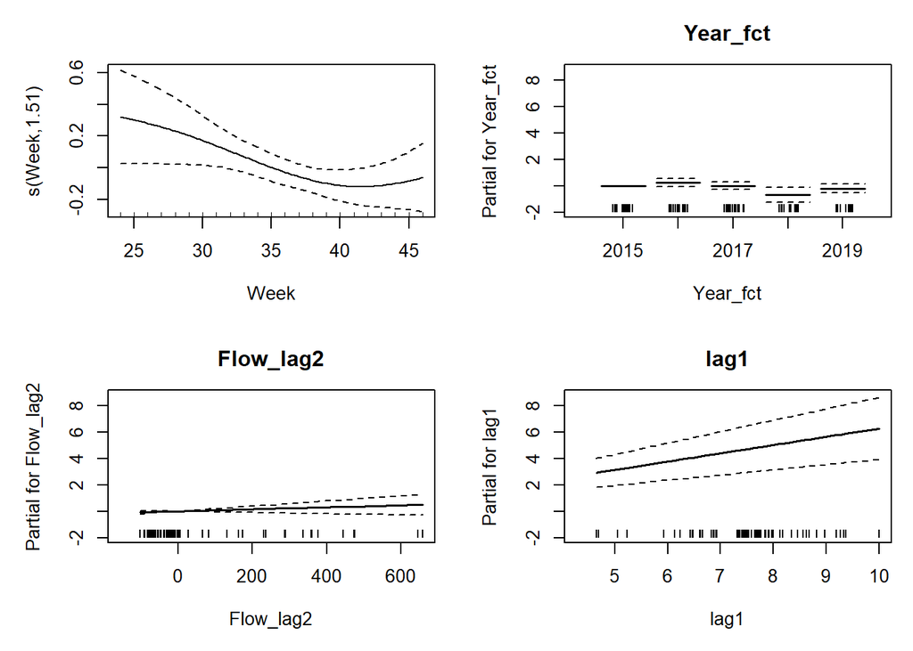

```r
anova(m_gam_lib_lag1)
```

```
##
## Family: gaussian
## Link function: identity
##
## Formula:
## Chla_log ~ Year_fct * Flow_lag2 + s(Week, bs = "cc", k = 5) +
##     lag1
##
## Parametric Terms:
##                    df      F  p-value
## Year_fct            4  1.694    0.164
## Flow_lag2           1  1.556    0.217
## lag1                1 28.439 1.63e-06
## Year_fct:Flow_lag2  4  0.437    0.782
##
## Approximate significance of smooth terms:
##           edf Ref.df    F p-value
## s(Week) 1.513  3.000 1.74  0.0352
```

The model diagnostics look a litle worse than the model without lag terms, but it’s corrected for autocorrelation. Before we proceed with this model for LIB, let’s take a closer look at how the back-transformed fitted values from the model match the observed values.

### Observed vs Fitted Values

```r
df_chla_lib_lag <- df_chla_lib |> drop_na(lag1)

# Sample sizes for each year
df_chla_lib_lag |> count(Year_fct)
```

```
## # A tibble: 5 × 2
##   Year_fct     n
##   <fct>    <int>
## 1 2015        18
## 2 2016        15
## 3 2017        15
## 4 2018        12
## 5 2019        11
```

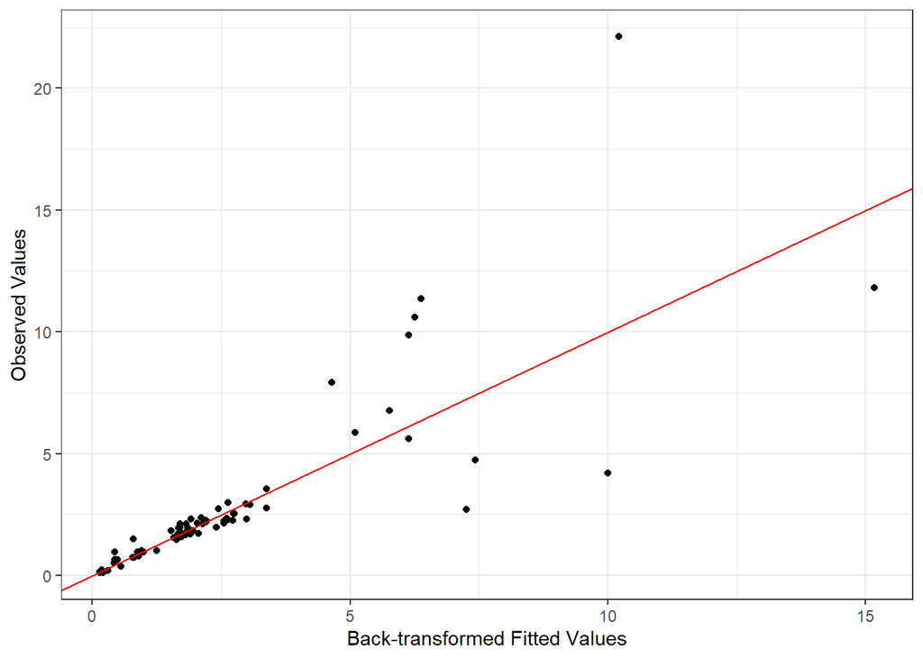

```r
plot_obs_vs_model_fit(m_gam_lib_lag1, df_chla_lib_lag)
```

The model fit looks pretty decent. Note that variability does increase as the chlorophyll values increase. Now, let’s look more closely at its results.

### Model Results

#### Effect of Flow by Year

Partial effect of flow on chlorophyll:

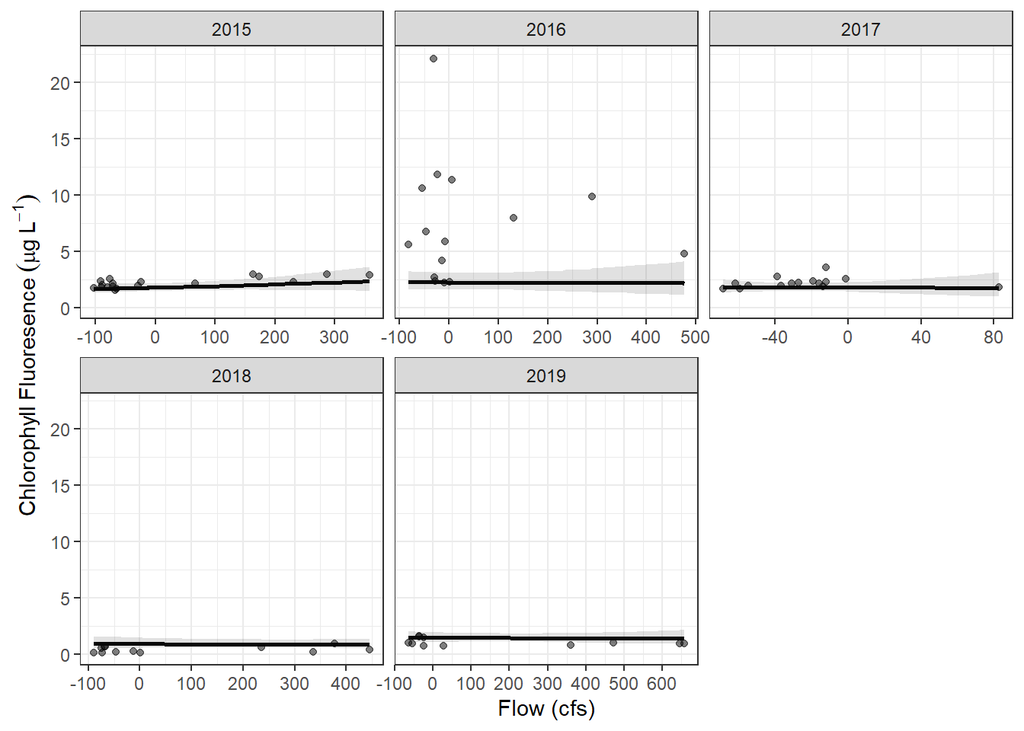

```r
# Calculate effects of flow on chlorophyll holding the non-focal variables constant -
# marginal effects/adjusted predictions
df_lib_flow_eff <- calc_flow_yr_marg_eff(
  m_gam_lib_lag1,
  df_chla_lib_lag,
  "Flow_lag2"
)

# Create effects plot
plot_eff_flow_by_yr(df_lib_flow_eff, df_chla_lib_lag, "Flow_lag2")
```

#### Year Contrasts

```r
# Estimated marginal means for year
em_lib_yr <- emmeans(m_gam_lib_lag1, ~Year_fct)

# Tukey post-hoc contrasts
pairs(em_lib_yr)
```

```
##  contrast                    estimate    SE   df t.ratio p.value
##  Year_fct2015 - Year_fct2016  -0.1867 0.157 58.5  -1.186  0.7591
##  Year_fct2015 - Year_fct2017   0.0456 0.228 58.5   0.200  0.9996
##  Year_fct2015 - Year_fct2018   0.7287 0.264 58.5   2.756  0.0577
##  Year_fct2015 - Year_fct2019   0.2482 0.163 58.5   1.525  0.5507
##  Year_fct2016 - Year_fct2017   0.2323 0.252 58.5   0.921  0.8878
##  Year_fct2016 - Year_fct2018   0.9154 0.348 58.5   2.632  0.0775
##  Year_fct2016 - Year_fct2019   0.4349 0.227 58.5   1.913  0.3223
##  Year_fct2017 - Year_fct2018   0.6831 0.321 58.5   2.130  0.2214
##  Year_fct2017 - Year_fct2019   0.2026 0.254 58.5   0.796  0.9306
##  Year_fct2018 - Year_fct2019  -0.4805 0.214 58.5  -2.245  0.1780
##
## P value adjustment: tukey method for comparing a family of 5 estimates
```

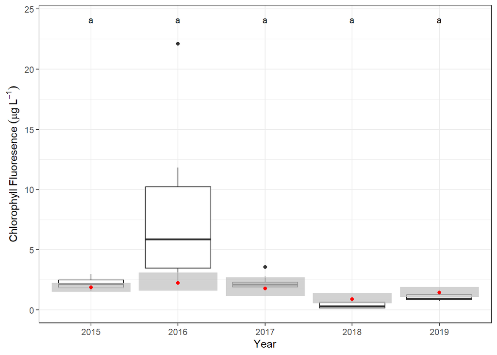

```r
# Create boxplot showing Tukey post-hoc results
boxplot_cont_yr(em_lib_yr, df_chla_lib_lag)
```

This time the model seems off for 2016. This is most likely because the lag1 term is explaining much of the variance. I think this model is okay for looking at the effects of flow by year, but not for differences between years.

## RVB

### Initial Model

```r
df_chla_rvb <- ls_chla_flow_lag$RVB |>
  select(-Flow) |>
  drop_na(Flow_lag3, Chla_log)

m_gam_rvb <- gam(
  Chla_log ~ Year_fct * Flow_lag3 + s(Week, bs = "cc", k = 5),
  data = df_chla_rvb,
  method = "REML",
  knots = list(Week = c(0, 52))
)
```

Lets look at the model summary and diagnostics:

```r
check_gam_diagnostics(m_gam_rvb)
```

```
## ==================================================
##           GAM MODEL DIAGNOSTICS
## ==================================================
##
## --- 1. MODEL SUMMARY ---
##
## Family: gaussian
## Link function: identity
##
## Formula:
## Chla_log ~ Year_fct * Flow_lag3 + s(Week, bs = "cc", k = 5)
##
## Parametric coefficients:
##                          Estimate Std. Error t value Pr(>|t|)
## (Intercept)             7.6186252  0.0490292 155.390  < 2e-16 ***
## Year_fct2016            0.0151918  0.0825560   0.184   0.8546
## Year_fct2017           -0.3390735  0.0811084  -4.181 9.40e-05 ***
## Year_fct2018           -0.3361156  0.0709362  -4.738 1.32e-05 ***
## Year_fct2019           -0.6872073  0.0734889  -9.351 2.08e-13 ***
## Flow_lag3              -0.0006823  0.0003611  -1.890   0.0636 .
## Year_fct2016:Flow_lag3 -0.0002422  0.0005034  -0.481   0.6321
## Year_fct2017:Flow_lag3  0.0001015  0.0015249   0.067   0.9471
## Year_fct2018:Flow_lag3  0.0004211  0.0004193   1.004   0.3192
## Year_fct2019:Flow_lag3  0.0005831  0.0003851   1.514   0.1351
## ---
## Signif. codes:  0 '***' 0.001 '**' 0.01 '*' 0.05 '.' 0.1 ' ' 1
##
## Approximate significance of smooth terms:
##           edf Ref.df     F  p-value
## s(Week) 2.711      3 8.669 3.51e-05 ***
## ---
## Signif. codes:  0 '***' 0.001 '**' 0.01 '*' 0.05 '.' 0.1 ' ' 1
##
## R-sq.(adj) =  0.761   Deviance explained = 79.9%
## -REML = 29.632  Scale est. = 0.037955  n = 74
##
## --- 2. BASIS DIMENSION CHECK (k.check) ---
##         k'      edf   k-index p-value
## s(Week)  3 2.711112 0.9691104  0.3625
##
## *Note: If p-value is low, the basis dimension 'k' might be too small.*
##
## --- 3. NORMALITY TEST OF RESIDUALS ---
##
##  Shapiro-Wilk normality test
##
## data:  resids
## W = 0.95785, p-value = 0.01469
##
## Result: Reject H0. Residuals are NOT normally distributed (p < 0.05).
##
## --- 4. GENERATING APPRAISE PLOTS ---
## Displaying: Residual QQ-plot, Residuals vs Linear Predictor, Histogram, and Observed vs Fitted.
```

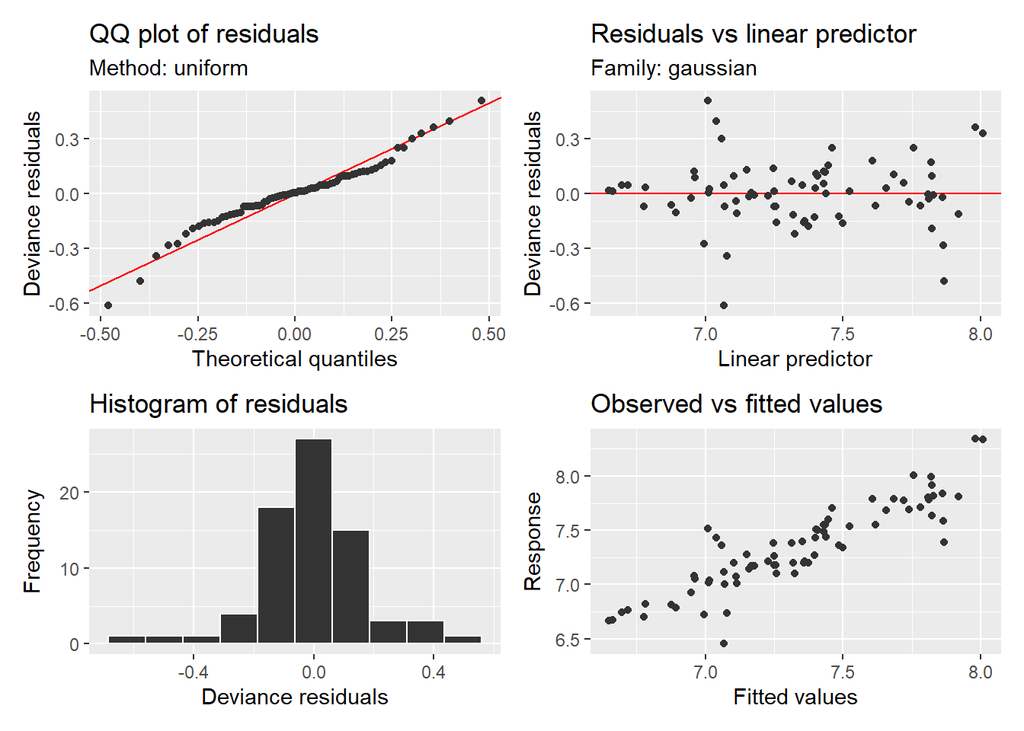

```
## --- 5. GENERATING SMOOTH TERM PLOTS ---
```

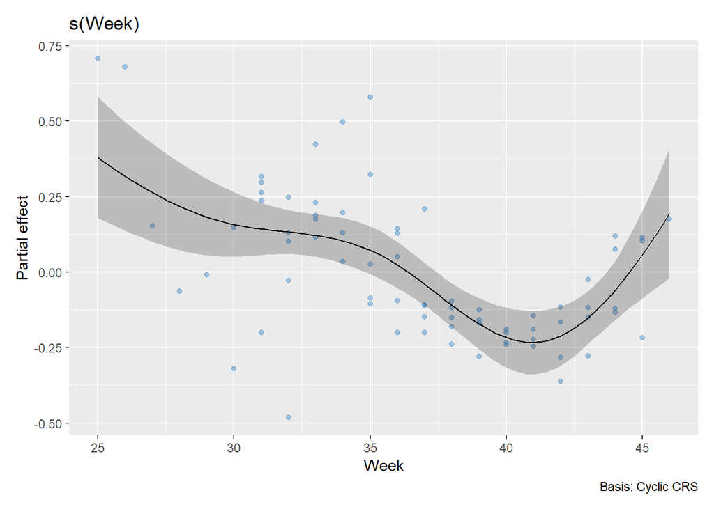

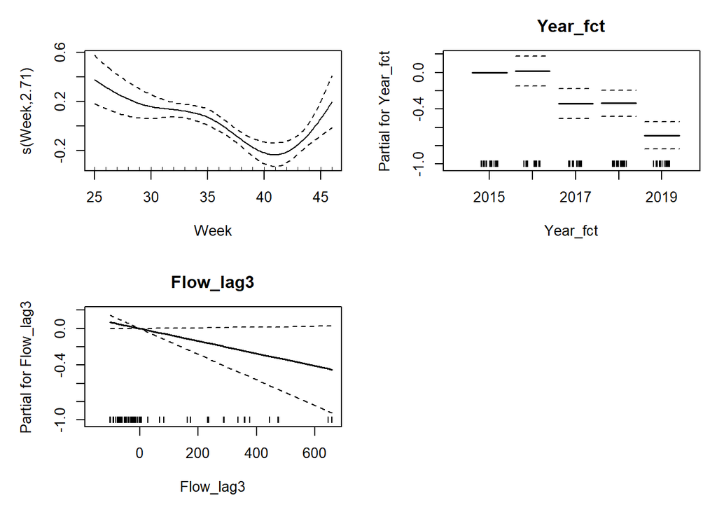

```r
check_gam_autocorr(m_gam_rvb)
```

```
## ==================================================
##        GAM RESIDUAL AUTOCORRELATION CHECK
## ==================================================
##
## --- 1. LJUNG-BOX TEST FOR SERIAL CORRELATION ---
##
##  Box-Ljung test
##
## data:  resids
## X-squared = 23.196, df = 20, p-value = 0.2793
##
## Result: Fail to reject H0. No significant residual autocorrelation (p >= 0.05).
##
## --- 2. PLOTTING AUTOCORRELATION FUNCTION (ACF) ---
```

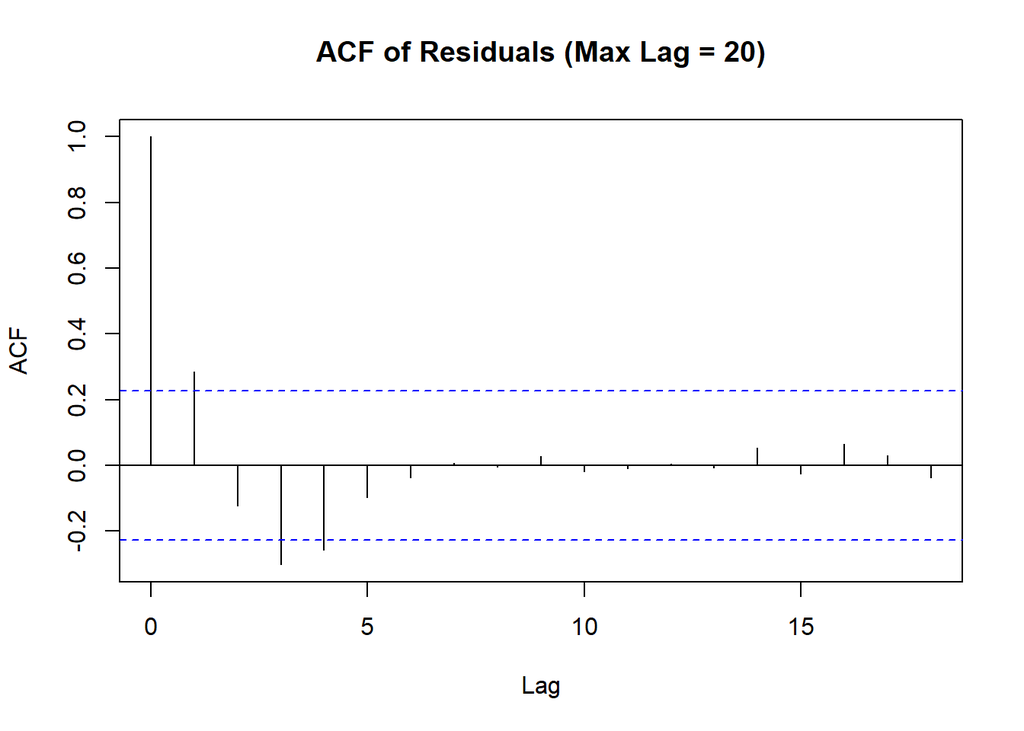

The diagnostic plots and stats look good. However, the residuals are slightly autocorrelated.

### Model with lag terms

Now, we’ll try to deal with the residual autocorrelation. We’ll run a series of models adding 1 and 2 lag terms and compare how well they correct for autocorrelation.

```r
m_gam_rvb_lag1 <- gam(
  Chla_log ~ Year_fct * Flow_lag3 + s(Week, bs = "cc", k = 5) + lag1,
  data = df_chla_rvb,
  method = "REML",
  knots = list(Week = c(0, 52))
)

check_gam_autocorr(m_gam_rvb_lag1)
```

```
## ==================================================
##        GAM RESIDUAL AUTOCORRELATION CHECK
## ==================================================
##
## --- 1. LJUNG-BOX TEST FOR SERIAL CORRELATION ---
##
##  Box-Ljung test
##
## data:  resids
## X-squared = 10.975, df = 20, p-value = 0.9469
##
## Result: Fail to reject H0. No significant residual autocorrelation (p >= 0.05).
##
## --- 2. PLOTTING AUTOCORRELATION FUNCTION (ACF) ---
```

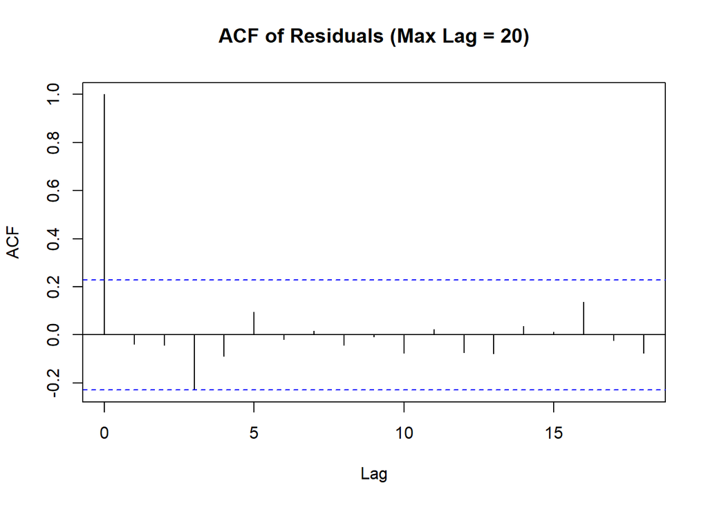

```r
m_gam_rvb_lag2 <- gam(
  Chla_log ~ Year_fct * Flow_lag3 + s(Week, bs = "cc", k = 5) + lag1 + lag2,
  data = df_chla_rvb,
  method = "REML",
  knots = list(Week = c(0, 52))
)

check_gam_autocorr(m_gam_rvb_lag2)
```

```
## ==================================================
##        GAM RESIDUAL AUTOCORRELATION CHECK
## ==================================================
##
## --- 1. LJUNG-BOX TEST FOR SERIAL CORRELATION ---
##
##  Box-Ljung test
##
## data:  resids
## X-squared = 14.431, df = 20, p-value = 0.808
##
## Result: Fail to reject H0. No significant residual autocorrelation (p >= 0.05).
##
## --- 2. PLOTTING AUTOCORRELATION FUNCTION (ACF) ---
```

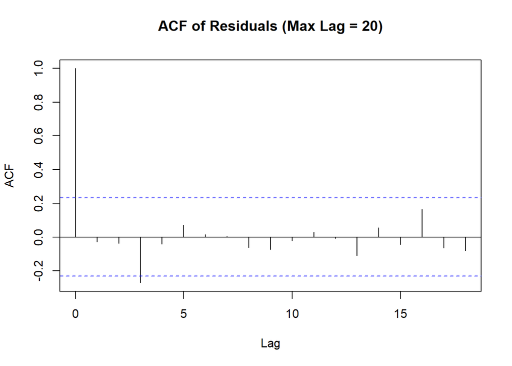

The model with 1 lag term seems to be okay with autocorrelation according to the acf plot. Adding a second lag term seems unnecessary. Let’s take a closer look at the model with 1 lag term.

```r
check_gam_diagnostics(m_gam_rvb_lag1)
```

```
## ==================================================
##           GAM MODEL DIAGNOSTICS
## ==================================================
##
## --- 1. MODEL SUMMARY ---
##
## Family: gaussian
## Link function: identity
##
## Formula:
## Chla_log ~ Year_fct * Flow_lag3 + s(Week, bs = "cc", k = 5) +
##     lag1
##
## Parametric coefficients:
##                          Estimate Std. Error t value Pr(>|t|)
## (Intercept)             4.4374656  0.7094637   6.255 4.39e-08 ***
## Year_fct2016           -0.0107512  0.0794509  -0.135 0.892807
## Year_fct2017           -0.2489971  0.0822884  -3.026 0.003631 **
## Year_fct2018           -0.2303186  0.0731982  -3.147 0.002558 **
## Year_fct2019           -0.3919876  0.0968250  -4.048 0.000148 ***
## Flow_lag3              -0.0008376  0.0003254  -2.574 0.012522 *
## lag1                    0.4188465  0.0925774   4.524 2.87e-05 ***
## Year_fct2016:Flow_lag3  0.0002272  0.0004622   0.492 0.624815
## Year_fct2017:Flow_lag3  0.0002050  0.0014570   0.141 0.888570
## Year_fct2018:Flow_lag3  0.0005158  0.0003990   1.293 0.201024
## Year_fct2019:Flow_lag3  0.0005877  0.0003660   1.606 0.113506
## ---
## Signif. codes:  0 '***' 0.001 '**' 0.01 '*' 0.05 '.' 0.1 ' ' 1
##
## Approximate significance of smooth terms:
##           edf Ref.df     F p-value
## s(Week) 1.199      3 0.858   0.124
##
## R-sq.(adj) =  0.775   Deviance explained =   81%
## -REML = 23.535  Scale est. = 0.03485   n = 73
##
## --- 2. BASIS DIMENSION CHECK (k.check) ---
##         k'      edf   k-index p-value
## s(Week)  3 1.198977 0.8776472  0.1025
##
## *Note: If p-value is low, the basis dimension 'k' might be too small.*
##
## --- 3. NORMALITY TEST OF RESIDUALS ---
##
##  Shapiro-Wilk normality test
##
## data:  resids
## W = 0.95419, p-value = 0.009799
##
## Result: Reject H0. Residuals are NOT normally distributed (p < 0.05).
##
## --- 4. GENERATING APPRAISE PLOTS ---
## Displaying: Residual QQ-plot, Residuals vs Linear Predictor, Histogram, and Observed vs Fitted.
```

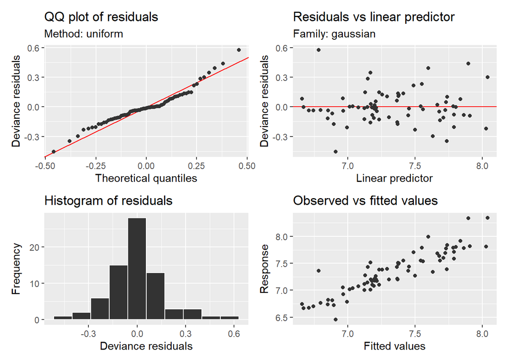

```
## --- 5. GENERATING SMOOTH TERM PLOTS ---
```

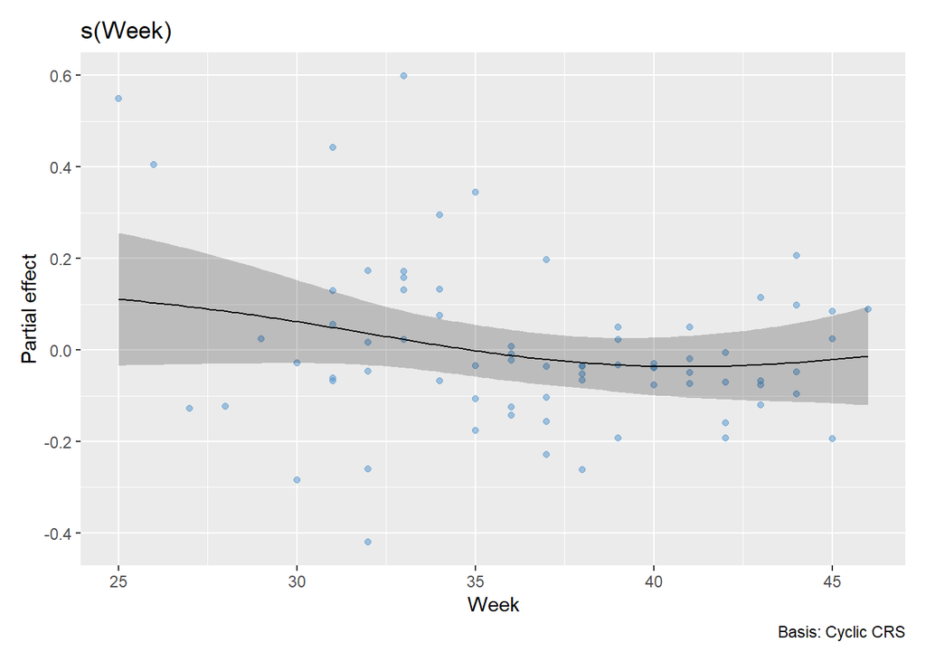

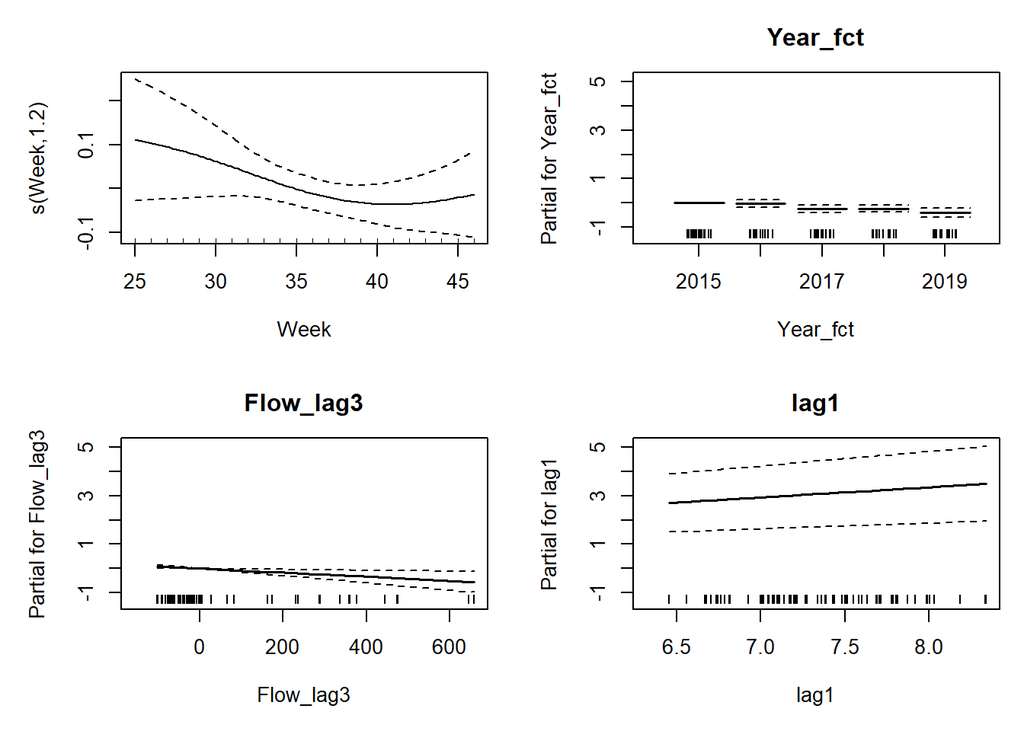

```r
anova(m_gam_rvb_lag1)
```

```
##
## Family: gaussian
## Link function: identity
##
## Formula:
## Chla_log ~ Year_fct * Flow_lag3 + s(Week, bs = "cc", k = 5) +
##     lag1
##
## Parametric Terms:
##                    df      F  p-value
## Year_fct            4  4.882  0.00176
## Flow_lag3           1  6.623  0.01252
## lag1                1 20.469 2.87e-05
## Year_fct:Flow_lag3  4  0.770  0.54899
##
## Approximate significance of smooth terms:
##           edf Ref.df     F p-value
## s(Week) 1.199  3.000 0.858   0.124
```

The model diagnostics look a litle worse than the model without lag terms, but it’s corrected for autocorrelation. Before we proceed with this model for RVB, let’s take a closer look at how the back-transformed fitted values from the model match the observed values.

### Observed vs Fitted Values

```r
df_chla_rvb_lag <- df_chla_rvb |> drop_na(lag1)

# Sample sizes for each year
df_chla_rvb_lag |> count(Year_fct)
```

```
## # A tibble: 5 × 2
##   Year_fct     n
##   <fct>    <int>
## 1 2015        17
## 2 2016        12
## 3 2017        14
## 4 2018        15
## 5 2019        15
```

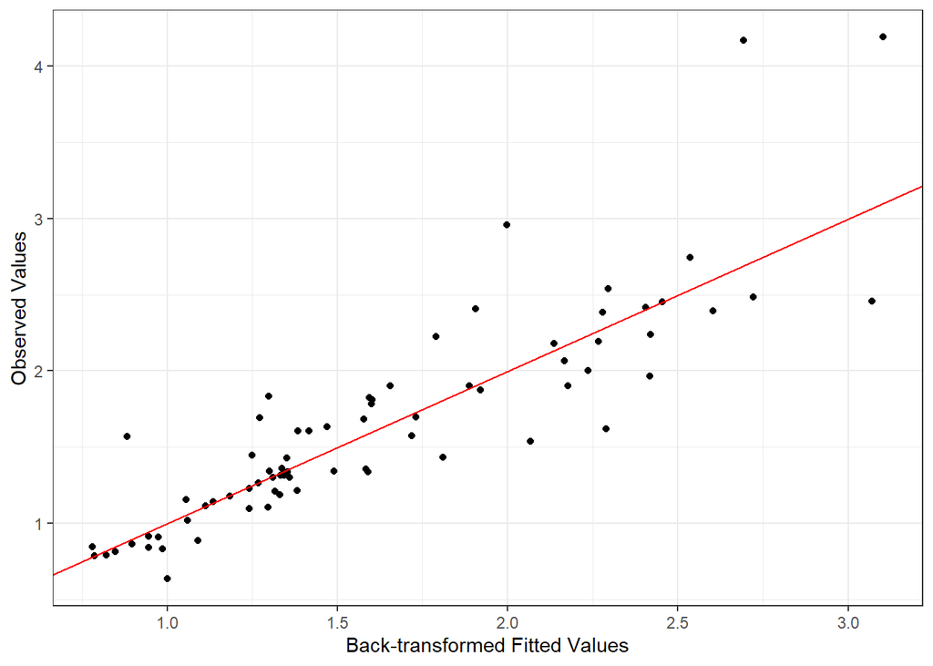

```r
plot_obs_vs_model_fit(m_gam_rvb_lag1, df_chla_rvb_lag)
```

The model fit looks pretty decent. Note that variability does increase as the chlorophyll values increase. Now, let’s look more closely at its results.

### Model Results

#### Effect of Flow by Year

Partial effect of flow on chlorophyll:

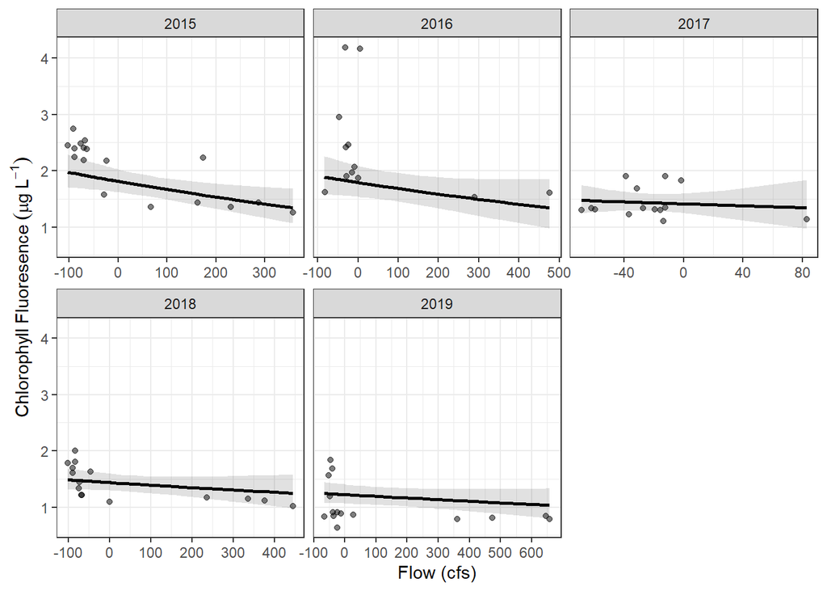

```r
# Calculate effects of flow on chlorophyll holding the non-focal variables constant -
# marginal effects/adjusted predictions
df_rvb_flow_eff <- calc_flow_yr_marg_eff(
  m_gam_rvb_lag1,
  df_chla_rvb_lag,
  "Flow_lag3"
)

# Create effects plot
plot_eff_flow_by_yr(df_rvb_flow_eff, df_chla_rvb_lag, "Flow_lag3")
```

#### Year Contrasts

```r
# Estimated marginal means for year
em_rvb_yr <- emmeans(m_gam_rvb_lag1, ~Year_fct)

# Tukey post-hoc contrasts
pairs(em_rvb_yr)
```

```
##  contrast                    estimate     SE   df t.ratio p.value
##  Year_fct2015 - Year_fct2016  0.00109 0.0785 60.8   0.014  1.0000
##  Year_fct2015 - Year_fct2017  0.24028 0.1200 60.8   2.009  0.2743
##  Year_fct2015 - Year_fct2018  0.20838 0.0716 60.8   2.909  0.0391
##  Year_fct2015 - Year_fct2019  0.36699 0.0932 60.8   3.936  0.0019
##  Year_fct2016 - Year_fct2017  0.23919 0.1290 60.8   1.861  0.3494
##  Year_fct2016 - Year_fct2018  0.20729 0.0871 60.8   2.381  0.1346
##  Year_fct2016 - Year_fct2019  0.36590 0.1070 60.8   3.417  0.0096
##  Year_fct2017 - Year_fct2018 -0.03190 0.1160 60.8  -0.275  0.9987
##  Year_fct2017 - Year_fct2019  0.12671 0.1210 60.8   1.046  0.8327
##  Year_fct2018 - Year_fct2019  0.15861 0.0788 60.8   2.012  0.2726
##
## P value adjustment: tukey method for comparing a family of 5 estimates
```

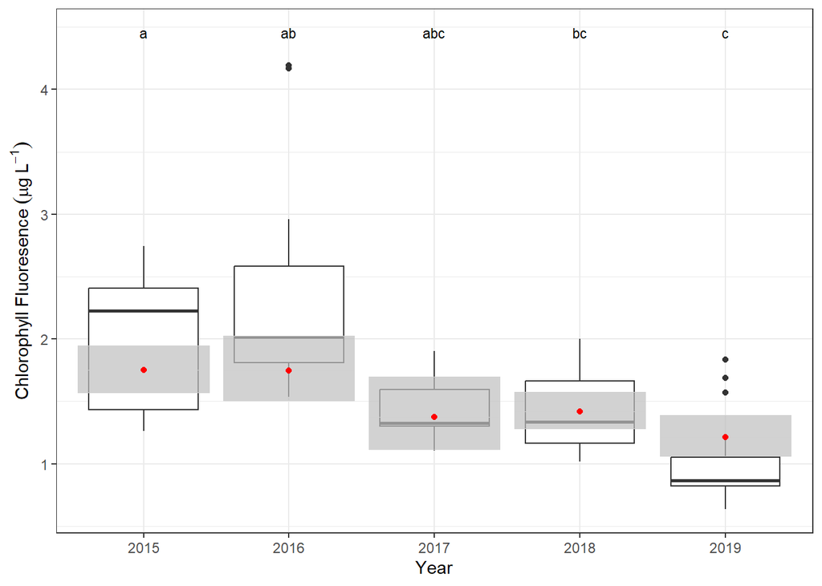

```r
# Create boxplot showing Tukey post-hoc results
boxplot_cont_yr(em_rvb_yr, df_chla_rvb_lag)
```

The year contrasts look okay, slightly off for 2016 and 2019 which is most likely because the lag1 term is explaining much of the variance. I think this model is okay for looking at the effects of flow by year, and could be used to look at differences between years.

# Conclusions

After looking at the results more closely from these models, I think they are adequate for predicting the effects of flow by year, but not at the differences between years.